# Practical Machine Learning - Course Project

## Synopsis

This report is part of Coursera **Practical Machine Learning** project. The goal of this project is to select **best Prediction Model** to classify the excercise patters of any participants as

- Class A : Exactly according to the specification
- Class B : Throwing the elbows to the front
- Class C : Lifting the dumbbell only halfway
- Class D : Lowering the dumbbell only halfway
- Class E : Throwing the hips to the front

with the raw data recorded from accelerometers/sensors on the belt, forearm, arm, and dumbell .Prediction can be done by training different model(Decision Tree,Random forest,GBM,SVM etc) with sample raw data collected from 6 participants and test it with the test data. Compare the accuracy of each model to select best model to **predict varaible Classe** with data of any Participants.The data for this project come from this source: http://groupware.les.inf.puc-rio.br/har.

## Data Processing

### Load Library and data:

Load the required library and Download both training and test data set from the link.

```r
#Load required library
library(caret);library(rpart);library(randomForest);library(rattle);library(rpart.plot)
setInternet2(TRUE)

#Download the data
# If a data directory does not exist, create the directory and download the data set into it.
if(!file.exists("./data")){
  dir.create("./data"); destfile1="./data/pml-testing.csv"; destfile2="./data/pml-training.csv"
  download.file("https://d396qusza40orc.cloudfront.net/predmachlearn/pml-testing.csv", destfile1)
  download.file("https://d396qusza40orc.cloudfront.net/predmachlearn/pml-training.csv", destfile2)
  }
traindata <- read.csv("./data/pml-training.csv", na.strings=c("NA",""), header=TRUE)
testdata <- read.csv("./data/pml-testing.csv", na.strings=c("NA",""), header=TRUE)

# Checking for the number of variables and observations
cat("Dimension of pml-training.csv : ",dim(traindata)); cat("Dimension of pml-testing.csv : ", dim(testdata));
```

```
## Dimension of pml-training.csv :  19622 160
```

```
## Dimension of pml-testing.csv :  20 160
```

### Pre-process Data:

- Remove those variables (user_name raw_timestamp_part_1 raw_timestamp_part_2 cvtd_timestamp new_window num_window) which will not provide much weightage for prediction
- Remove near zero covariates
- Remove Columns with more than 80% missing values

```r
Cleandata <- function(dataFrame){
# 1.  Deleting variables containing User,timestamp and window size which are not used ( Columns 1 to 7)
    subsetTraining <- dataFrame[,-c(1:7)]

# 2. Remove near Zero covariates
    nsv <- nearZeroVar(subsetTraining, saveMetrics = T)
    subsetTraining <- subsetTraining[,!nsv$nzv]

# 3. Remove Variables  that have more than  80% threshold of NA's
  nav <- sapply(colnames(subsetTraining), function(x)
  if(sum(is.na(subsetTraining[, x])) > 0.8*nrow(subsetTraining)){return(T)}else{return(F)})
    procTraining <- subsetTraining[, !nav]

}
Cleantrain<-Cleandata(traindata);
dim(Cleantrain);
```

```
## [1] 19622    53
```

The training set has 19622 samples and 52 (excluding the “classe” variable) potential predictors after cleaning.

### Partition Data:

To estimate the out-of-sample error, randomly split the full training data into two sets as training (70%) and testing (30%).

```r
# split data into two parts
set.seed(123)
inTrain <- createDataPartition(y=Cleantrain$classe, p=0.7, list=FALSE)
training <- Cleantrain[inTrain,]
testing <- Cleantrain[-inTrain,]
```

## Machine Learning Models Evaluation Process

### Train Models:

Train the Splitted data with **classification tree and Random Forest Model**

- **Train Training Data with Classification tree model**

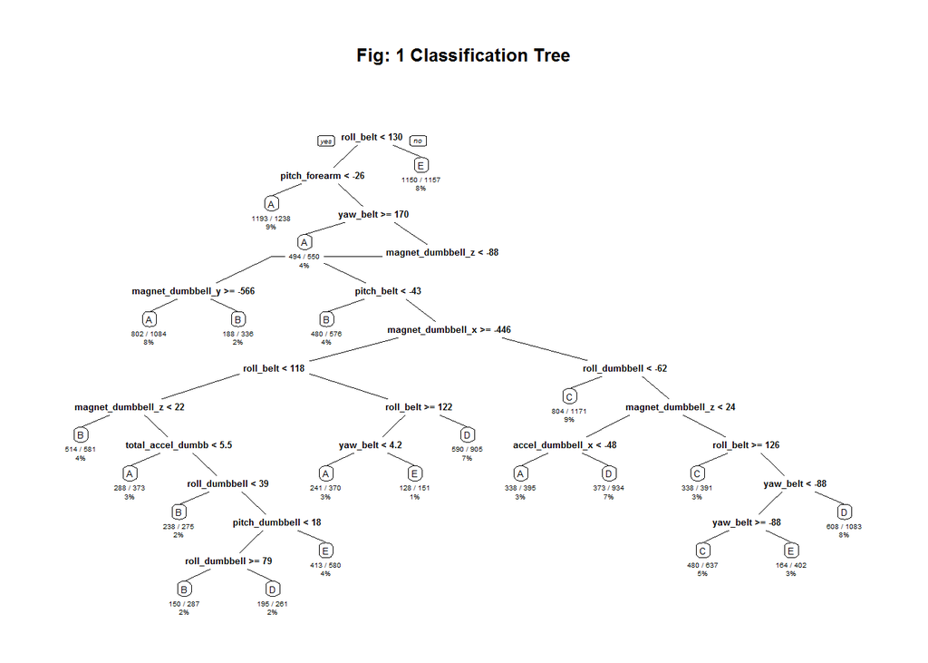

```r
## Classification tree model
modFitCtm <- rpart(classe ~ ., data=training, method="class")
#fancyRpartPlot(modFitCtm,under.cex= 0.9) # Plot nder text is too small to view in html
rpart.plot(modFitCtm, main="Fig: 1 Classification Tree", extra=102, under=TRUE, faclen=0)
```

- **Train Training Data with Random forest model**

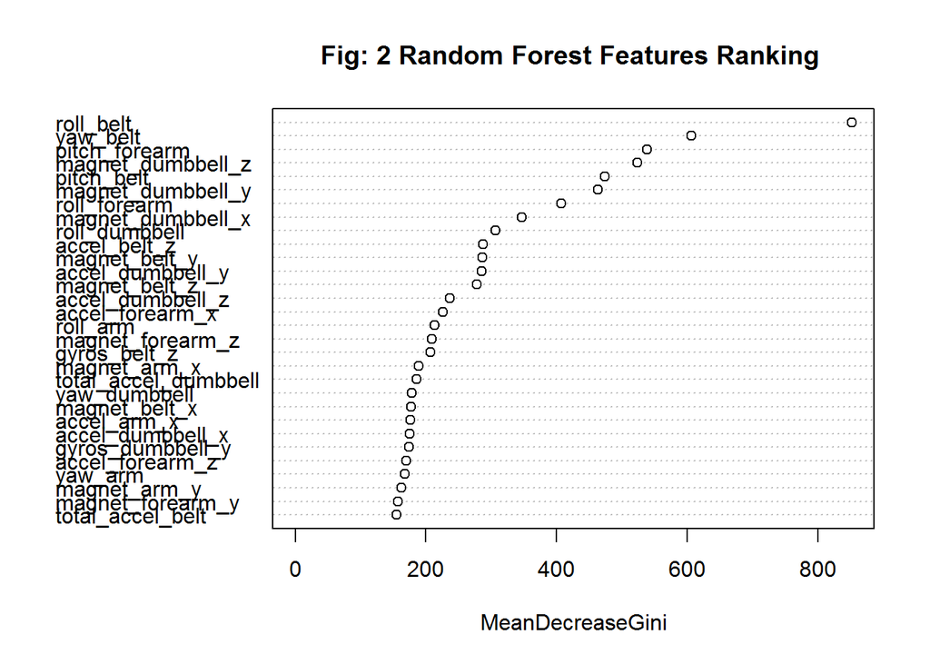

```r
## Random forest Model
modFitRfm <- randomForest(classe ~. , data=training);
varImpPlot(modFitRfm ,main="Fig: 2 Random Forest Features Ranking ")
```

### Predict Test data with Trained Models:

To find the best fitted model, test our splitted 30 % of test dataset against each model as shown below

- **Predict Testing Data with Classification tree model**

```r
## Classification tree model
prediction1 <- predict(modFitCtm, testing,type = "class")
ctm<-confusionMatrix(prediction1, testing$classe)
ctm$table
```

```
##           Reference
## Prediction    A    B    C    D    E
##          A 1424  184   52   56   25
##          B   26  667   54   48   70
##          C   33  107  701   53   52
##          D  167  106  193  735  157
##          E   24   75   26   72  778
```

- **Predict Testing Data with Random forest Model**

```r
## Random forest Model
prediction2 <- predict(modFitRfm, testing)
rfm<-confusionMatrix(prediction2, testing$classe)
rfm$table
```

```
##           Reference
## Prediction    A    B    C    D    E
##          A 1673    6    0    0    0
##          B    1 1133   12    0    0
##          C    0    0 1014   14    0
##          D    0    0    0  949    0
##          E    0    0    0    1 1082
```

### Compare Accuracy of Models:

- **Accuracy of Classification tree model**

```r
ctm$overall
```

```
##       Accuracy          Kappa  AccuracyLower  AccuracyUpper   AccuracyNull
##   7.315208e-01   6.606323e-01   7.200004e-01   7.428113e-01   2.844520e-01
## AccuracyPValue  McnemarPValue
##   0.000000e+00   1.580765e-66
```

- **Accuracy of Random Forest model**

```r
rfm$overall
```

```
##       Accuracy          Kappa  AccuracyLower  AccuracyUpper   AccuracyNull
##      0.9942226      0.9926910      0.9919359      0.9959958      0.2844520
## AccuracyPValue  McnemarPValue
##      0.0000000            NaN
```

```r
rfmAccur <- rfm$overall['Accuracy']
```

Random Forest model Accuracy 0.9942226 is much better in comparing to Classification tree model Accuracy 0.7315208.

## Best Model Selection and Prediction

Comparing model accuracy of the two above generated models -random forests and classification tree, **Random forests model** has overall better accuracy.Estimated **out of sample error rate** for the random forests model is 0.0057774 which is very low

### Prediction with best model:

Predict the given new test set through best model **Random Forest** and output results (Predicted Value of Classe Variable) for automatic grader of coursera Submission.

```r
# predict on test set
(prediction <- as.character(predict(modFitRfm, newdata=testdata)))
```

```
##  [1] "B" "A" "B" "A" "A" "E" "D" "B" "A" "A" "B" "C" "B" "A" "E" "E" "A"
## [18] "B" "B" "B"
```

```r
# create function to write predictions to files
pml_write_files <- function(x) {
    n <- length(x)
    for(i in 1:n) {
        filename <- paste0("./output/problem_id_", i, ".txt")
        write.table(x[i], file=filename, quote=F, row.names=F, col.names=F)
    }
}

# create prediction files to submit
pml_write_files(prediction)
```

## Conclusion

From the above process ,it look like **Randow forest Model is overfit** with accuracy of 0.9942226 with the given processed trained data . However, we cannot expect the model to predict with same accuracy with different set of situations like all data collected with no NA and/or using different device, then we may need to retrain model to perform same as shown in the analysis or it may fail to predict with better accuracy.